# June 10: Investigating investment curves

# Exploring investment dynamics

I will explore the investment dynamics with three different scenarios. The scenarios are given by the following initial conditions:

```r
IC_1 <- c(
  # Economic variables
  Y_N       =  30,       # global GDP, in trillions of USD
  d_N       =  1.5,      # private debt ratio of the economy
  lambda_N  =  0.67,     # employment rate of the global economy
  omega_N   =  0.58,     # wage share of the economy
  N_N       =  2.4,      # Workforce of the (world) economy, in billions /2
  g_sigma_N =  -0.0105,  # Growth rate of the emissions intensity of the economy
  n_N       =  0.03,     # Emissions reduction rate
  E_ind_N   =  18,       # Industrial CO2-e emissions, in Gt CO2-e

  # Climate variables - unchanged in all scenarios
  CO2_AT   =  851,      # CO2-e concentration in the atmosphere layer, in Gt C
  CO2_UP   =  460,      # CO2-e concentration in the biosphere and upper ocean layer, in Gt C
  CO2_LO   =  1740,     # CO2-e concentration in the deep ocean layer, in Gt C
  E_land   =  2.6,      # Exogenous land use change CO2-e emissions, in Gt CO2-e
  p        =  1,        # Composite good price level
  p_BS     =  547.22,   # Backstop technology price level
  Temp     =  0.85,     # Temperature in the atmosphere, biosphere, and upper ocean layer, in degrees Celsius
  Temp_LO  =  0.0068    # Temperature in the deep ocean layer, in degrees Celsius
)

IC_2 <- c(
  # Economic variables
  Y_N       =  40,       # changed
  d_N       =  0.6,      # changed
  lambda_N  =  0.9,     # changed
  omega_N   =  0.6,      # changed
  N_N       =  2.4,
  g_sigma_N =  -0.0105,
  n_N       =  0.03,
  E_ind_N   =  18,

  # Climate variables - unchanged in all scenarios
  CO2_AT   =  851,
  CO2_UP   =  460,
  CO2_LO   =  1740,
  E_land   =  2.6,
  p        =  1,
  p_BS     =  547.22,
  Temp     =  0.85,
  Temp_LO  =  0.0068
)

IC_3 <- c(
  # Economic variables
  Y_N       =  20,       # changed
  d_N       =  2,        # changed
  lambda_N  =  0.5,      # changed
  omega_N   =  0.45,
  N_N       =  2.4,
  g_sigma_N =  -0.0105,
  n_N       =  0.03,
  E_ind_N   =  18,

  # Climate variables - unchanged in all scenarios
  CO2_AT   =  851,
  CO2_UP   =  460,
  CO2_LO   =  1740,
  E_land   =  2.6,
  p        =  1,
  p_BS     =  547.22,
  Temp     =  0.85,
  Temp_LO  =  0.0068
)
```

Running the three scenarios from above gives the following:

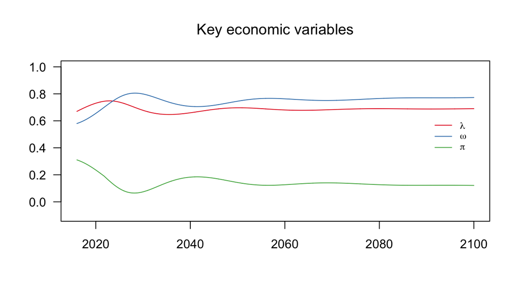

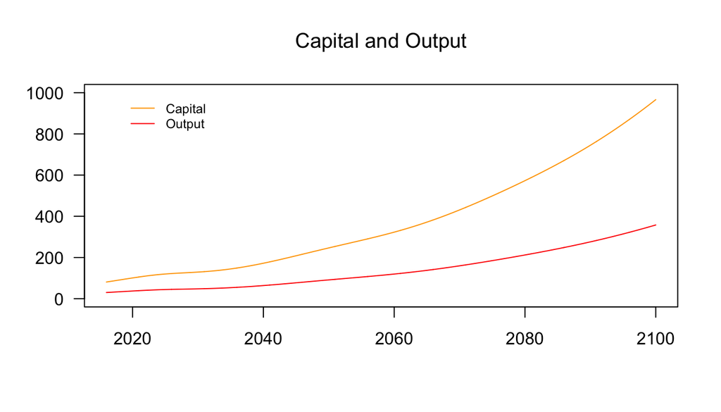

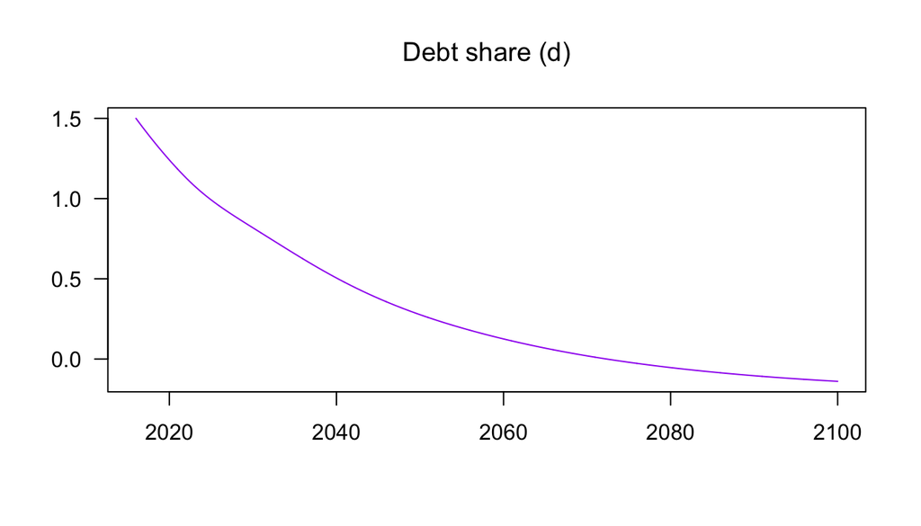

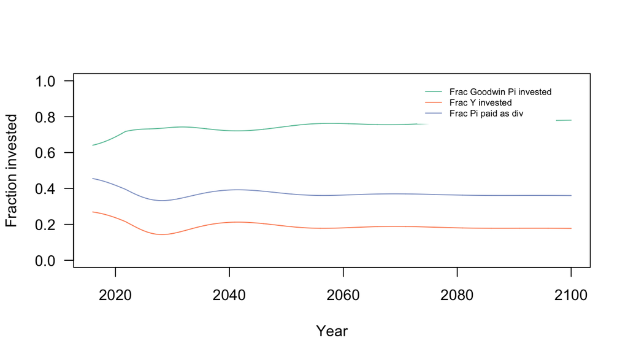

```r
# Set up simulation
Time <- c(
  start         =     2016,
  end           =     2100,
  step          =     0.05,
  start_p_Car_N =     2016
)

Active <- list(
  Damage_N     =   'None',       # None / Nordhaus / Weitzman / Stern
  Damage_K     =    0,           # Fraction of damages allocated to capital
  Temperature  =    TRUE,        # T / F
  Lab_Prod_N   =   'constant',   # constant / Burke
  p_Car_N      =   'None',       # None / Low / Medium / High / Canada
  s_A_N        =   0,            # fraction of abatement costs subsidized by government
  Phillips     =   'linear',     # linear / asymptotic
  Invest       =   'linear'      # linear / arctan
)

#================================================================================
## Run a scenario
# Initial conditions from Bovari et al. (2018) (Y=30, d=1.5, lambda=0.67, omega=0.58)
Simulation1 <- simulation(time             = Time,
                          init_sim         = IC_1,
                          pars             = Pars,
                          active           = Active,
                          method           = 'lsoda',
                          show_end_results = FALSE,
                          show_graph       = T
)
```

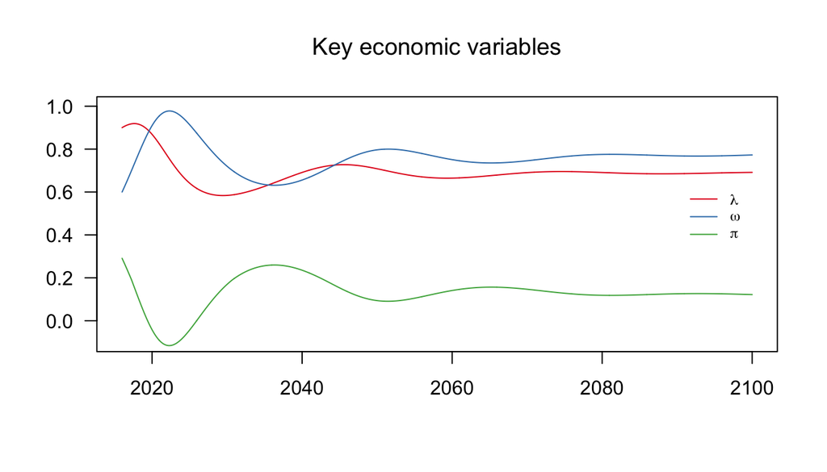

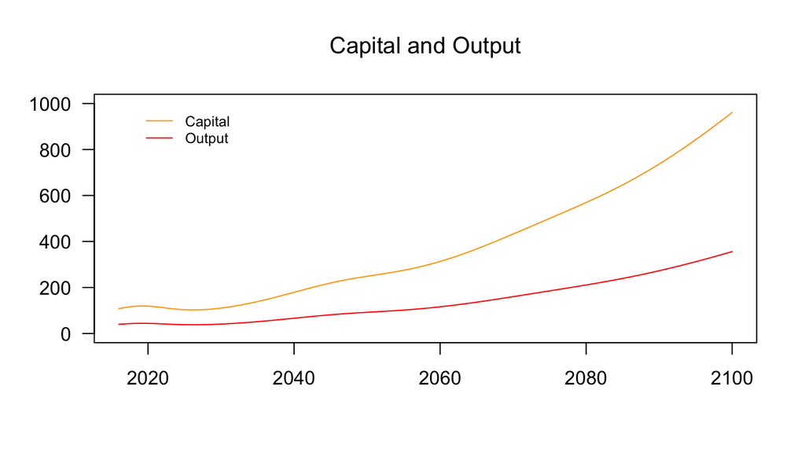

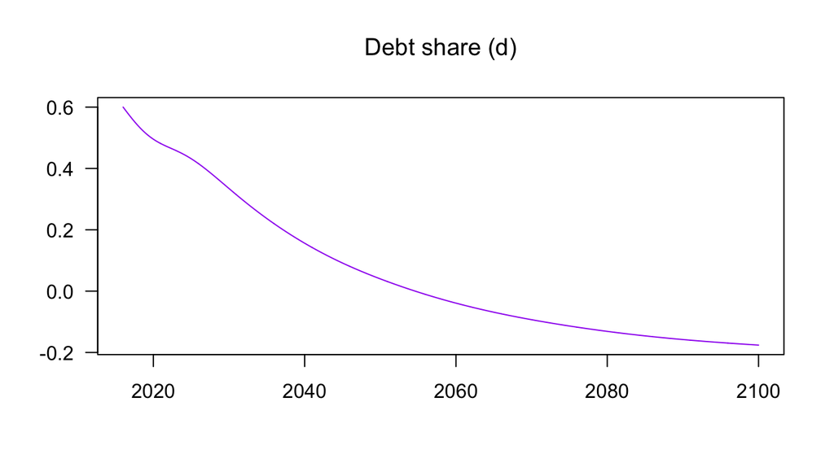

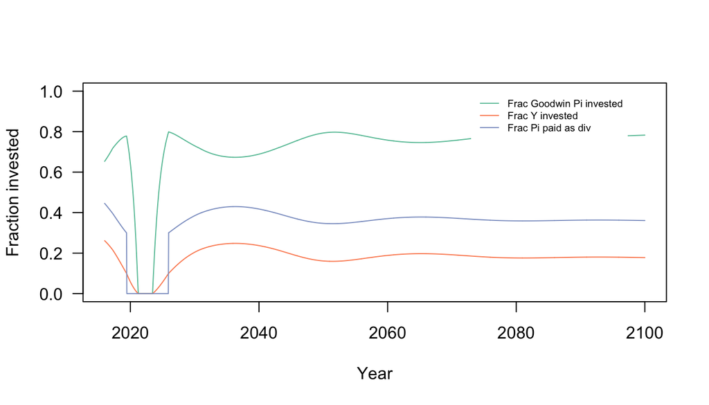

```r
# low debt share, high employment (Y=40, d=0.6, lambda=0.9, omega=0.6)
Simulation2 <- simulation(time             = Time,
                          init_sim         = IC_2,
                          pars             = Pars,
                          active           = Active,
                          method           = 'lsoda',
                          show_end_results = FALSE,
                          show_graph       = T
)
```

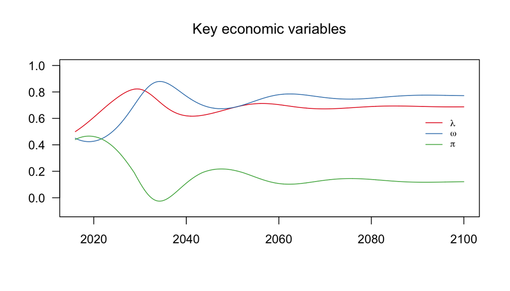

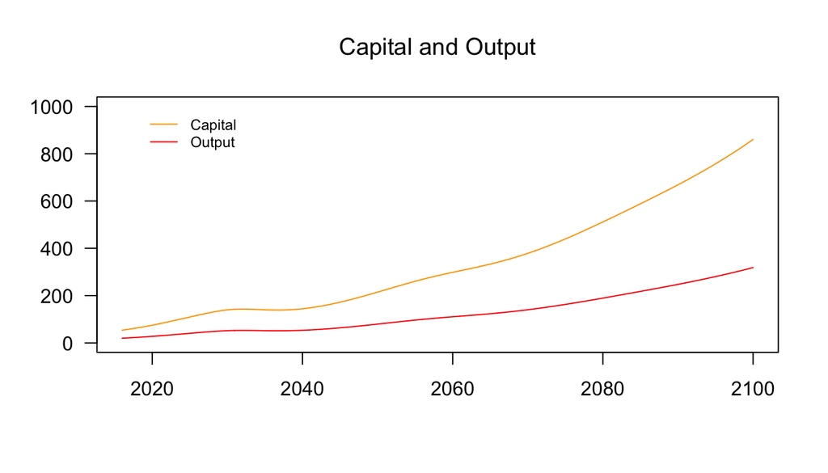

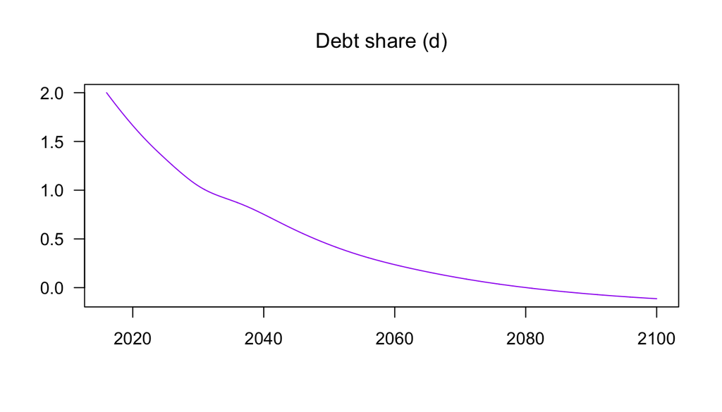

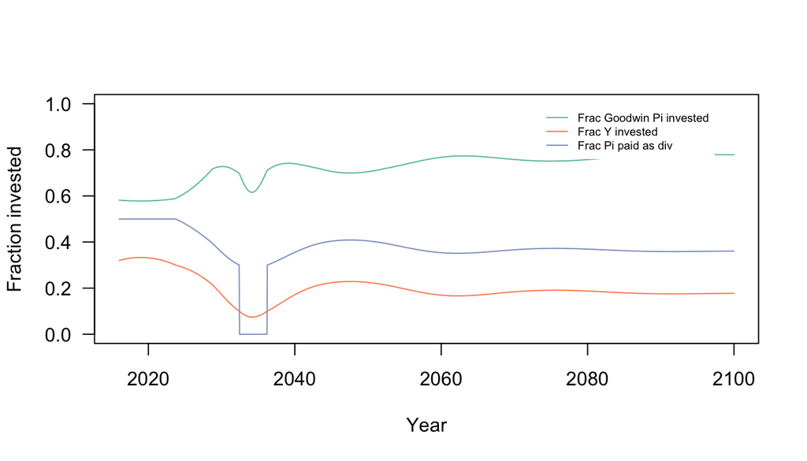

```r
# high debt share, low employment (Y=20, d=2, lambda=0.5, omega=0.45)
Simulation3 <- simulation(time             = Time,
                          init_sim         = IC_3,
                          pars             = Pars,
                          active           = Active,
                          method           = 'lsoda',
                          show_end_results = FALSE,
                          show_graph       = T
)
```

It is worth noting that with this specification the model doesn’t approach the bad equilibrium even with very poor initial conditions (ex. d=5, lambda=0.4, Y=5). This is true with both the linear and non-linear Phillips curve.